# Writing Functions

R Pruim

CVC 2016

## Automating Plot Generation

Yesterday we grabbed data on HIV prevalance from GapMinder, and after a bit of clean up, we created a plot. I’ve saved the data as an Rds file, so we can skip the clean up for now and focus on the plot

```r
HIVdata <- readRDS("HIVdata.Rds") # available in CVC2016readonly
head(HIVdata, 3)
```

```
## Source: local data frame [3 x 3]
##
##                 country  year HIV.perc
##                   <chr> <dbl>    <dbl>
## 1              Abkhazia  1979       NA
## 2           Afghanistan  1979       NA
## 3 Akrotiri and Dhekelia  1979       NA
```

Here’s a plot we made with this data.

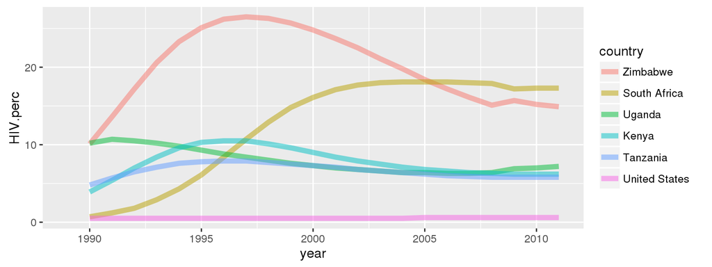

```r
HIVdata %>%
  filter(country %in% c("Uganda", "Kenya", "Tanzania", "South Africa",
                        "Zimbabwe", "United States")) %>%
  filter(year > 1988) %>%
  mutate(country =
           reorder(country, HIV.perc,
                   function(x) - max(x, na.rm = TRUE))) %>%
  ggplot(aes(x = year, y = HIV.perc, color = country)) +
  geom_line(size = 2, alpha = 0.5)
```

Actually, I’ve added one new feature to the plot. I’ve reordered the levels of `country` so that the lines in the legend are in roughly the same order as the lines on the plot.

Now let’s turn this into a simple (and not particularly useful) function.

```r
HIVplot <- function() {
  HIVdata %>%
    filter(country %in% c("Uganda", "Kenya", "Tanzania", "South Africa",
                          "Zimbabwe", "United States")) %>%
    filter(year > 1988) %>%
    mutate(country =
             reorder(country, HIV.perc,
                     function(x) - max(x, na.rm = TRUE))) %>%
    ggplot(aes(x = year, y = HIV.perc, color = country)) +
    geom_line(size = 2, alpha = 0.5)
}
```

Notice that the only difference is the first and last lines. The first line indicates that we are going to create a function named `HIVplot` and the portion between the curly braces is the definition. The object created by the last expression in the function body is returned - in this case, the plot.

As is, the funciton is not so useful, becuase it doesn’t have any arguments, so it can only create the same plot repeatedly. But even this can be useful for tasks that you want to repeat frequently in exactly the same way – it can save a lot of typing:

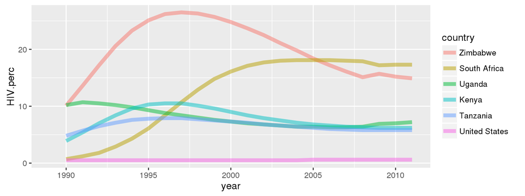

```r
HIVplot()
```

We can generalize this by adding some arguments that let us change features of the plot. For example, we could add the abilty to adjust the width of the lines as follows:

```r
HIVplot2 <- function(linewidth = 2) {
  HIVdata %>%
    filter(country %in% c("Uganda", "Kenya", "Tanzania", "South Africa",
                          "Zimbabwe", "United States")) %>%
    filter(year > 1988) %>%
    mutate(country =
             reorder(country, HIV.perc,
                     function(x) - max(x, na.rm = TRUE))) %>%
    ggplot(aes(x = year, y = HIV.perc, color = country)) +
    geom_line(size = linewidth, alpha = 0.5)
}
```

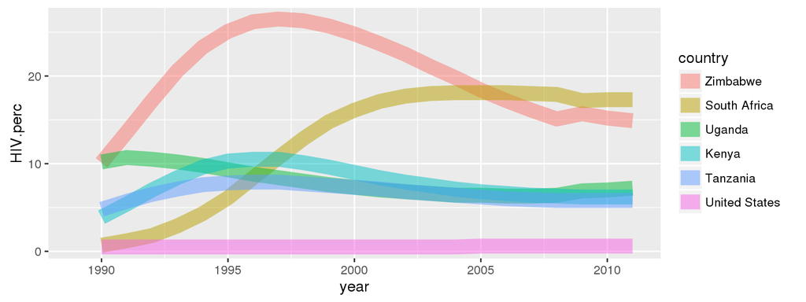

```r
HIVplot2(linewidth = 5)
```

In a similar way, we can add several arguments to our function. Let’s add the following:

- `data`: the name of our data set (in case we have data with a different name later)
- `indicator`: the name of the column that contains the data to be plotted against time. GapMinder calls these indicators, so we are borrowing their terminology. (As a fancy bonus, we’ll call `match.arg()` to allow for abbreviation of the name.)
- `countries`: the countries we want to display
- `linewidth`: the thickness of the lines that we draw
- `first_year`: the first year we want to display
- `opacity`: how opaque the lines are (between 0 and 1)

Below we create a function with these arguments, and then in the body of the function, plug them in in the appropriate places.

Here are few things to know about the new function definition.

1. Default values of the the arguments can be specified in the function declaration. That way, we don’t have to provide a value for every argument. Arguments can be specified by (unique prefix of) a name or by position. It is a common practice in R to use the first arguement or two without names and then to use names for the other arguments, which will typically have default values so that only those being overridden need to be specified.
2. Because our indicator variable is described by a character string, we need to use `aes_string()` rather than `aes()` to describe the aesthetics.
3. Our new function can plot time series for any data wet that has columns named `country` and `year` and an additional column containing the “indicator” to be plotted. So we should give the function a name that reflects this generality. We could call it `GapminderPlot()`, since it is designed to work with GapMinder data sets, or we could name it `TimeSeriesPlot()`, although it is not very flexibly designed for arbitrary time series data.
4. We could make this even more general if we allowed column names to be specified for `country` and `year` as well as `indicator`. Deciding how general to make a function is an important part of the design. Often you will return to functions later to make them more general becuase you find that they almost do some other task you didn’t think of when you originally wrote the function.

```r
GapMinderPlot <-
  function(
    data,
    indicator,
    countries = c( "South Africa", "Zimbabwe", "United States"),
    linewidth = 1.2,
    first_year = min(~year, data = data),
    opacity = .8
    )
    {

  # this finds indicator among the names of the variables even if it is abbreviated
  # to a unique prefix.
  indicator <- match.arg(indicator, names(data))

  data %>%
    filter(country %in% countries) %>%
    filter(year >= first_year) %>%
    ggplot(aes_string(x = "year", y = indicator, color = "country")) +
    geom_line(size = linewidth, alpha = opacity)
}
```

Now we can make a plot using our function

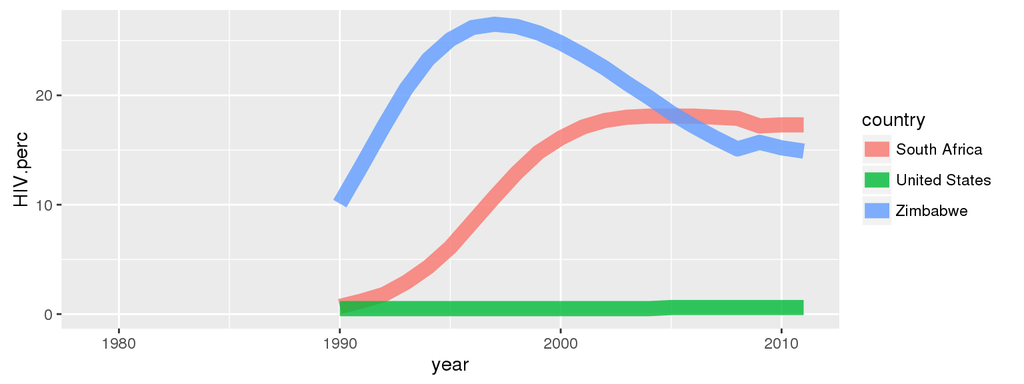

```r
GapMinderPlot( HIVdata, "HIV", linewidth = 4)
```

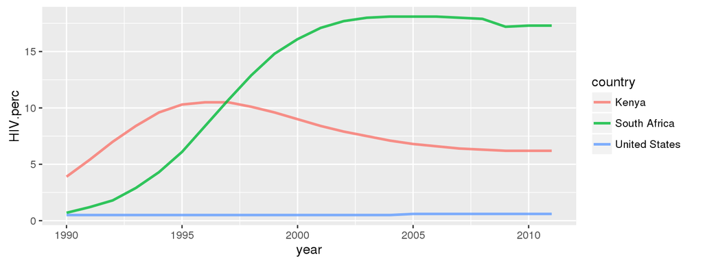

```r
GapMinderPlot( HIVdata, "HIV",
               countries = c("United States", "South Africa", "Kenya"),
               first_year = 1990,
               linewidth = 1)
```

We have lost one feature in this version. We have lost the reordering of the countries. This can be reintroduced, but it is tricky to do it with mutate since we don’t know the name of the variable to be reordered when we are writing the function. (It is determined by the user’s value of `indicator`, which is a character string.) Below is one way to do it.

While we are at it, let’s make the default value of `indicator` be the name of the third column of `data` (where it will be located if the data are processed from GapMinder the way we have done it).

```r
GapMinderPlot <-
  function(
    data,
    indicator = names(data)[3],
    countries = c( "South Africa", "Zimbabwe", "United States"),
    linewidth = 1.2,
    first_year = min(~year, data = data),
    opacity = .8
    )
    {

  # this finds indicator among the names of the variables even if it is abbreviated
  # to a unique prefix.
  indicator <- match.arg(indicator, names(data))

  data <- data %>%
    filter(country %in% countries) %>%
    filter(year >= first_year)

  data[["country"]] <-
    reorder(data[["country"]], data[[indicator]], function(x) - max(x, na.rm = TRUE))

  data %>%
    ggplot(aes_string(x = "year", y = indicator, color = "country")) +
    geom_line(size = linewidth, alpha = opacity)
}
```

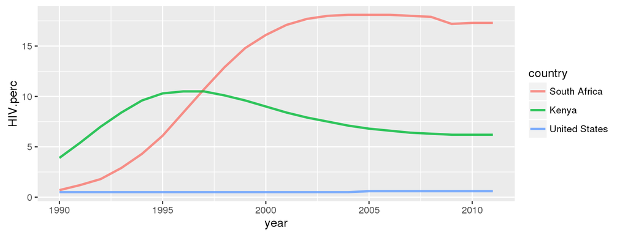

```r
GapMinderPlot( HIVdata,
               countries = c("United States", "South Africa", "Kenya"),
               first_year = 1990,
               linewidth = 1)
```

## Loading Data from GapMinder

Now let’s create a function that can read in data from a GapMinder spreadhseet and reformat the resutling data so that is is glyph ready for our plot.

```r
require(googlesheets)
load_gapminder <- function( url, name = "value") {
  google_connection <- gs_url( url, visibility = "public" )

  # using the dimensions of the spread sheet, read the portion
  # that contains data.  Specifying the range should not be necessary
  # for newer google sheets.
  result <-
    gs_read(google_connection,
            range = cell_limits(c(1,1),
                                c(google_connection$ws$row_extent[1],
                                  google_connection$ws$col_extent[1]))
    )

  # name the first column country
  names(result)[1] <- "country"

  # convert from wide to long format
  result <-
    result %>%
    gather( year, value, -country ) %>%
    mutate( year = extract_numeric(year))

  # rename the indicator column
  names(result)[3] <- name
  result    # returned value since it is the last line evaluated
}
```

```r
hiv_url <-
  "https://docs.google.com/spreadsheets/d/1kWH_xdJDM4SMfT_Kzpkk-1yuxWChfurZuWYjfmv51EA/pub?gid=0"
HIVdata2 <- load_gapminder(hiv_url, name = "HIV.perc")
```

```
## Sheet-identifying info appears to be a browser URL.
## googlesheets will attempt to extract sheet key from the URL.
```

```
## Putative key: 1kWH_xdJDM4SMfT_Kzpkk-1yuxWChfurZuWYjfmv51EA
```

```
## Worksheets feed constructed with public visibility
```

```
## Accessing worksheet titled 'Data'.
```

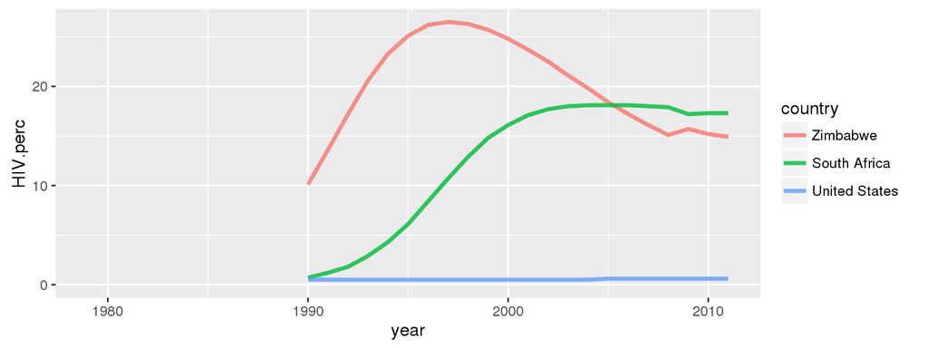

```r
GapMinderPlot(HIVdata2, "HIV.perc")
```

We can also load other GapMinder spreadsheets by supplying a different URL. Here is life expectency data.

```r
le_url <-
  "https://docs.google.com/spreadsheets/d/1H3nzTwbn8z4lJ5gJ_WfDgCeGEXK3PVGcNjQ_U5og8eo/pub?gid=0"
LifeExpectency <- load_gapminder( le_url, name = "life.expectancy" )
```

```
## Sheet-identifying info appears to be a browser URL.
## googlesheets will attempt to extract sheet key from the URL.
```

```
## Putative key: 1H3nzTwbn8z4lJ5gJ_WfDgCeGEXK3PVGcNjQ_U5og8eo
```

```
## Worksheets feed constructed with public visibility
```

```
## Accessing worksheet titled 'Data'.
```

We can now use our plotting function with any of these data sets.

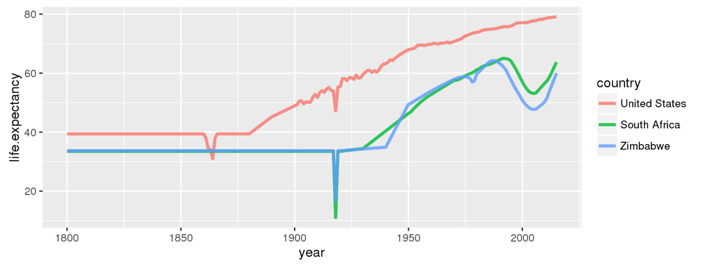

```r
GapMinderPlot( LifeExpectency )
```

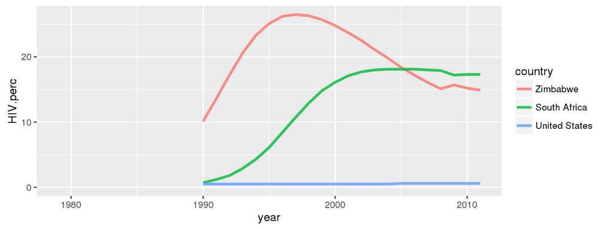

```r
GapMinderPlot( HIVdata )
```

Note that because our function returns a ggplot object, we can “add” to it just like to any other ggplot object.

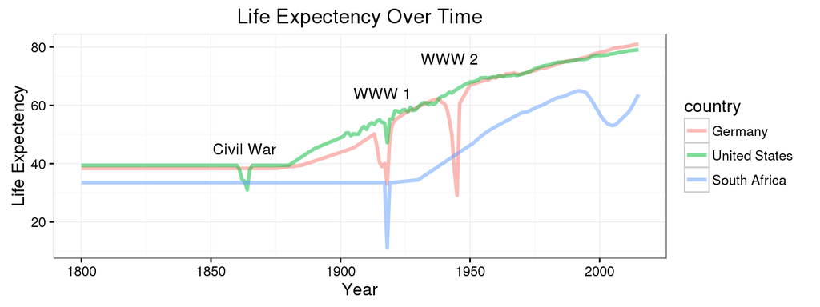

```r
GapMinderPlot( LifeExpectency, opacity=0.5, countries=c("United States", "Germany", "South Africa") ) +
  labs(y = "Life Expectency", x = "Year", title = "Life Expectency Over Time") +
  theme_bw() +
  annotate("text", x= 1863, y=45, label = "Civil War") +
  annotate("text", x= 1916, y=64, label = "WWW 1") +
  annotate("text", x= 1942, y=76, label = "WWW 2")
```

## The Big Picture

1. If you find yourself wanting to copy a chunk of code, make one little change, and then run it again, then you are likely in a situation where a function would be useful.
2. You can begin your function by wrapping your code chunk in

```r
my_function_name <- function () {

  # old code goes here

}
```

3. Now choose one small thing that you would like to be able to vary. Provide a name for the argument and a default value (if there is a reasonable default) and replace the specific value in your code with the argument name from your function declaration.
4. Keep an eye out for ways you could make your function more general than your immediate task. Not only does that make your function more widely useful, but often the function is easier to write, and clearer to read if it is a bit more general.
5. But build up slowly. Don’t go crazy with 27 complicated options all at once. You can add in new arguments one at a time or in small groups of arguments that work together.
6. If your function will be useful in multiple files or projects, you should consider putting it into a package. Simple packages created for your own use are not that hard to build. Once you have made your package, you can simply `require()` it in any file or project where you want to use your new function. It is also easy to share packages with others who might be interested in using your function.
7. Comment your code. Don’t write comments for simple code that is clear by itself, but do write comments
- for complicated code where it might not be immediately clear what is happening
- explaining **why** you are doing things
- outlining the **big picture** (how you are thinking about the task at hand)
- alerting the reader to subtleties (or with students, unfamiliar functions or new features of the langauge.)
8. But don’t confuse comments with text that belongs in a proper document.

## Exercises

1. Make `GapMinderPlot` more general by allowing the user to select columns rather than requiring that they be called `country` and `year`.
2. Write a data loading function for a kind of data you expect to encounter frequently.
3. Write a plotting function for a kind of plot you anticipate making frequently.